# Project: The Movie Data Analysis (TMDb)

# Introduction

In this project, we are going to analyze data about 10,000 movies collected from The Movie Database (TMDb), including user ratings and revenue we will be interested in finding answers to the following questions:

1. Who are the directors who most direct films?
2. Who are the most actors who have played a starring roles in movies?
3. How is the revenue associated to the average voting score?
4. How is the revenue associated to the different genres ?
5. How is the genres associated to the average voting score? and does this associacion reflect on the revenue?
6. Does the budget increase has an effect on revenue?

### Note:

1. The final two columns ending with “_adj” show the budget and revenue of the associated movie in terms of 2010 dollars, accounting for inflation over time.
2. Certain columns, like ‘cast’ and ‘genres’, contain multiple values separated by pipe (|) characters.
3. There are some odd characters in the ‘cast’ column. Don’t worry about cleaning them. You can leave them as is.

# Start here

```python
# This cell to set up import statements for all of the packages that I plan to use.
import pandas as pd
import matplotlib.pyplot as plt
import seaborn as sns
%matplotlib inline
```

## Data Wrangling

### General Properties

```python
# LoadING data from tmbd-movies.csv file.
movie = pd.read_csv('tmdb-movies.csv')
```

```python
# Get information about the columns indcies , Data frame shape, the type of the values in each column and the number of each
# non-null values in each column
movie.info()
```

```
<class 'pandas.core.frame.DataFrame'>
RangeIndex: 10866 entries, 0 to 10865
Data columns (total 21 columns):
 #   Column                Non-Null Count  Dtype
---  ------                --------------  -----
 0   id                    10866 non-null  int64
 1   imdb_id               10856 non-null  object
 2   popularity            10866 non-null  float64
 3   budget                10866 non-null  int64
 4   revenue               10866 non-null  int64
 5   original_title        10866 non-null  object
 6   cast                  10790 non-null  object
 7   homepage              2936 non-null   object
 8   director              10822 non-null  object
 9   tagline               8042 non-null   object
 10  keywords              9373 non-null   object
 11  overview              10862 non-null  object
 12  runtime               10866 non-null  int64
 13  genres                10843 non-null  object
 14  production_companies  9836 non-null   object
 15  release_date          10866 non-null  object
 16  vote_count            10866 non-null  int64
 17  vote_average          10866 non-null  float64
 18  release_year          10866 non-null  int64
 19  budget_adj            10866 non-null  float64
 20  revenue_adj           10866 non-null  float64
dtypes: float64(4), int64(6), object(11)
memory usage: 1.7+ MB
```

```python
# Check rondom sample of the newly created movie data frame checking the formating and other issues if exist
movie.sample(10)
```

|  | id | imdb_id | popularity | budget | revenue | original_title | cast | homepage | director | tagline | ... | overview | runtime | genres | production_companies | release_date | vote_count | vote_average | release_year | budget_adj | revenue_adj |
| --- | --- | --- | --- | --- | --- | --- | --- | --- | --- | --- | --- | --- | --- | --- | --- | --- | --- | --- | --- | --- | --- |
| 8350 | 19143 | tt0104107 | 0.089502 | 17000000 | 4836637 | Diggstown | James Woods\|Louis Gossett, Jr.\|Bruce Dern\|Oliv... | NaN | Michael Ritchie | Where the pros meet the cons. | ... | Gabriel Caine has just been released from pris... | 98 | Action\|Comedy\|Drama | Metro-Goldwyn-Mayer (MGM)\|Eclectic Films | 8/14/92 | 11 | 6.3 | 1992 | 2.641841e+07 | 7.516251e+06 |
| 6539 | 868 | tt0468565 | 0.075624 | 3000000 | 9879971 | Tsotsi | Presley Chweneyagae\|Jerry Mofokeng\|Terry Pheto... | http://www.tsotsimovie.com/ | Gavin Hood | In this world... Redemption comes just once. | ... | The South African multi-award winning film abo... | 94 | Crime\|Drama | Movieworld Productions\|Industrial Development ... | 8/18/05 | 42 | 6.8 | 2005 | 3.349690e+06 | 1.103161e+07 |
| 2066 | 44244 | tt1252380 | 0.653800 | 0 | 0 | Camp Rock 2: The Final Jam | Demi Lovato\|Alyson Stoner\|Joe Jonas\|Nick Jonas... | http://tv.disney.go.com/disneychannel/original... | Paul Hoen | NaN | ... | Mitchie can't wait to go back to Camp Rock and... | 97 | TV Movie\|Drama\|Comedy\|Music\|Romance | Walt Disney Television\|Alan Sacks Productions | 6/6/10 | 185 | 5.5 | 2010 | 0.000000e+00 | 0.000000e+00 |
| 3780 | 73562 | tt1931470 | 0.202351 | 0 | 0 | La guerre est déclarée | Valérie Donzelli\|Jérémie Elkaïm\|Gabriel El... | NaN | Valérie Donzelli | NaN | ... | A young couple wrestle with their child's canc... | 100 | Drama | Rectangle Productions. | 5/10/11 | 41 | 7.1 | 2011 | 0.000000e+00 | 0.000000e+00 |
| 9944 | 10514 | tt0066769 | 0.357413 | 6500000 | 0 | The Andromeda Strain | Arthur Hill\|David Wayne\|James Olson\|Kate Reid\|... | NaN | Robert Wise | The picture runs 130 minutes!... The story cov... | ... | When virtually all of the residents of Piedmon... | 131 | Science Fiction\|Thriller | Universal Pictures | 3/12/71 | 70 | 6.7 | 1971 | 3.500377e+07 | 0.000000e+00 |
| 5281 | 9770 | tt0119592 | 0.761870 | 50000000 | 10541523 | Mad City | John Travolta\|Dustin Hoffman\|Mia Kirshner\|Alan... | NaN | Costa-Gavras | One man will make a mistake. The other will ma... | ... | A misguided museum guard who loses his job and... | 114 | Action\|Drama\|Thriller | Warner Bros.\|Arnold Kopelson Productions | 11/7/97 | 36 | 5.3 | 1997 | 6.792302e+07 | 1.432024e+07 |
| 184 | 316002 | tt1137470 | 0.813893 | 26000000 | 0 | Accidental Love | Jake Gyllenhaal\|Jessica Biel\|James Marsden\|Cat... | NaN | David O. Russell\|Stephen Greene | Sometimes you nail love. Sometimes it nails you. | ... | A small town waitress gets a nail accidentally... | 100 | Romance\|Comedy | K. JAM Media | 2/10/15 | 64 | 3.6 | 2015 | 2.391999e+07 | 0.000000e+00 |
| 7979 | 19400 | tt0087903 | 0.133098 | 0 | 1337274 | Gwendoline | Tawny Kitaen\|Brent Huff\|Zabou Breitman\|Bernade... | NaN | Just Jaeckin | NaN | ... | A beautiful woman hires an intrepid adventurer... | 88 | Adventure\|Fantasy\|Thriller | Films de L'Alma\|G.P.F.I.\|Parafrance Films | 2/7/84 | 11 | 3.9 | 1984 | 0.000000e+00 | 2.806994e+06 |
| 8430 | 21515 | tt0083133 | 0.140980 | 0 | 0 | Student Bodies | Kristen Riter\|Matthew Goldsby\|Jerry Belson\|Joe... | NaN | Mickey Rose\|Michael Ritchie | 13½ Murders + 1423 Laughs = Student Bodies | ... | Director Mickey Rose's zany send-up of teen sl... | 86 | Comedy\|Horror\|Mystery | Paramount Pictures | 8/7/81 | 13 | 4.8 | 1981 | 0.000000e+00 | 0.000000e+00 |
| 8989 | 9798 | tt0120660 | 1.303667 | 90000000 | 250649836 | Enemy of the State | Will Smith\|Gene Hackman\|Jon Voight\|Lisa Bonet\|... | NaN | Tony Scott | It's not paranoia if they're really after you | ... | Hotshot Washington lawyer Robert Dean becomes ... | 132 | Action\|Drama\|Thriller | Jerry Bruckheimer Films\|Scott Free Productions... | 11/20/98 | 815 | 6.5 | 1998 | 1.203926e+08 | 3.352931e+08 |

10 rows × 21 columns

## Data Cleaning :

### Note:

The final two columns ending with “_adj” show the budget and revenue of the associated movie in terms of 2010 dollars, accounting for inflation over time.

```python
# 1- Remove OF unrequired columns including budget and revenue as they are modified to take infilation into account
# in budget_adj and revenue_adg
# Drop columns based on column index.
movie.drop(movie.columns[[0,1, 3,4,7,9,10,11,14,15]],axis = 1,inplace=True)
# Chech a 10 random rows as a sample for the whole data frame after the columns removal
movie.sample(10)
```

|  | popularity | original_title | cast | director | runtime | genres | vote_count | vote_average | release_year | budget_adj | revenue_adj |
| --- | --- | --- | --- | --- | --- | --- | --- | --- | --- | --- | --- |
| 4171 | 0.063246 | VeggieTales: Jonah | Phil Vischer\|Mike Nawrocki\|Tim Hodge\|Lisa Visc... | Mike Nawrocki\|Phil Vischer | 82 | Action\|Adventure\|Animation\|Comedy\|Family | 17 | 6.1 | 2002 | 0.000000e+00 | 0.000000e+00 |
| 2448 | 0.937873 | Bicentennial Man | Robin Williams\|Sam Neill\|Embeth Davidtz\|Oliver... | Chris Columbus | 131 | Comedy\|Science Fiction | 538 | 6.7 | 1999 | 1.309053e+08 | 1.226583e+08 |
| 5219 | 0.059976 | Indiana Jones: Making the Trilogy | Harrison Ford\|George Lucas\|Steven Spielberg\|La... | Laurent Bouzereau | 127 | Documentary | 10 | 7.2 | 2003 | 0.000000e+00 | 0.000000e+00 |
| 10344 | 0.286492 | Children of the Corn II: The Final Sacrifice | Terence Knox\|Paul Scherrer\|Ryan Bollman\|Christ... | David Price | 92 | Horror\|Mystery | 15 | 4.7 | 1993 | 1.358523e+06 | 1.053759e+07 |
| 10659 | 0.344172 | The Party at Kitty and Stud's | Sylvester Stallone\|Henrietta Holm\|Nicholas War... | Morton Lewis | 71 | NaN | 10 | 3.0 | 1970 | 2.808184e+04 | 0.000000e+00 |
| 8034 | 0.290596 | Lone Wolf McQuade | Chuck Norris\|David Carradine\|Barbara Carrera\|L... | Steve Carver | 107 | Action\|Thriller\|Drama\|Western\|Crime | 27 | 5.2 | 1983 | 1.094656e+07 | 2.678104e+07 |
| 4984 | 1.414421 | The Animatrix | Keanu Reeves\|Carrie-Anne Moss\|Clayton Watson\|P... | Peter Chung\|Yoshiaki Kawajiri\|Takeshi Koike\|Ma... | 102 | Animation\|Science Fiction | 258 | 6.6 | 2003 | 5.926763e+06 | 0.000000e+00 |
| 189 | 0.781809 | The Benefactor | Dakota Fanning\|Theo James\|Richard Gere\|Clarke ... | Andrew Renzi | 90 | Drama | 55 | 4.5 | 2015 | 0.000000e+00 | 0.000000e+00 |
| 2520 | 0.573718 | The Story of Us | Bruce Willis\|Michelle Pfeiffer\|Rob Reiner\|Coll... | Rob Reiner | 95 | Comedy\|Drama\|Romance | 42 | 5.9 | 1999 | 6.545264e+07 | 7.710325e+07 |
| 4023 | 0.535827 | The Banger Sisters | Goldie Hawn\|Susan Sarandon\|Geoffrey Rush\|Erika... | Bob Dolman | 98 | Comedy\|Drama | 32 | 5.3 | 2002 | 1.212261e+07 | 0.000000e+00 |

```python
# Investigate duplications
movie.duplicated().sum()
```

```
1
```

```python
# Investigate of null values in each columns after removing the unrequired columns
movie.isnull().sum()
```

```
popularity         0
original_title     0
cast              76
director          44
runtime            0
genres            23
vote_count         0
vote_average       0
release_year       0
budget_adj         0
revenue_adj        0
dtype: int64
```

```python
# Investigate the values that equal to zero in each column
(movie == 0).sum()
```

```
popularity           0
original_title       0
cast                 0
director             0
runtime             31
genres               0
vote_count           0
vote_average         0
release_year         0
budget_adj        5696
revenue_adj       6016
dtype: int64
```

```python
# 2- Deleting duplicationed, null and zero values
for x in movie.columns:
    movie = movie.drop_duplicates()
    movie = movie.loc[movie[x] != 0]
    movie = movie.dropna()
```

```python
# Check for the null values after the removal
movie.isnull().sum()
```

```
popularity        0
original_title    0
cast              0
director          0
runtime           0
genres            0
vote_count        0
vote_average      0
release_year      0
budget_adj        0
revenue_adj       0
dtype: int64
```

```python
# Check for the shape, the type of the values in each column and the number of each
# non-null values in each column in movie data frame after the removal step
movie.info()
```

```
<class 'pandas.core.frame.DataFrame'>
Int64Index: 3849 entries, 0 to 10848
Data columns (total 11 columns):
 #   Column          Non-Null Count  Dtype
---  ------          --------------  -----
 0   popularity      3849 non-null   float64
 1   original_title  3849 non-null   object
 2   cast            3849 non-null   object
 3   director        3849 non-null   object
 4   runtime         3849 non-null   int64
 5   genres          3849 non-null   object
 6   vote_count      3849 non-null   int64
 7   vote_average    3849 non-null   float64
 8   release_year    3849 non-null   int64
 9   budget_adj      3849 non-null   float64
 10  revenue_adj     3849 non-null   float64
dtypes: float64(4), int64(3), object(4)
memory usage: 360.8+ KB
```

```python
# Check 10 rows rondom sample of movie data frame after deleting duplicationed, null and zero values
movie.sample(10)
```

|  | popularity | original_title | cast | director | runtime | genres | vote_count | vote_average | release_year | budget_adj | revenue_adj |
| --- | --- | --- | --- | --- | --- | --- | --- | --- | --- | --- | --- |
| 33 | 3.648210 | Bridge of Spies | Tom Hanks\|Mark Rylance\|Amy Ryan\|Alan Alda\|Seba... | Steven Spielberg | 141 | Thriller\|Drama | 1638 | 7.1 | 2015 | 3.679998e+07 | 1.496016e+08 |
| 842 | 0.646337 | The Pyramid | Ashley Hinshaw\|Denis O'Hare\|James Buckley\|Chri... | Grégory Levasseur | 89 | Horror | 234 | 4.7 | 2014 | 5.987092e+06 | 1.277133e+07 |
| 2565 | 0.246669 | 200 Cigarettes | Ben Affleck\|Casey Affleck\|Dave Chappelle\|Kate ... | Risa Bramon Garcia | 101 | Comedy\|Drama\|Romance | 25 | 6.5 | 1999 | 7.854317e+06 | 8.970219e+06 |
| 8130 | 0.640869 | Rob Roy | Liam Neeson\|Jessica Lange\|John Hurt\|Tim Roth\|E... | Michael Caton-Jones | 139 | Adventure | 72 | 6.2 | 1995 | 4.006707e+07 | 4.521413e+07 |
| 1457 | 1.039442 | The Unborn | Odette Annable\|Gary Oldman\|Meagan Good\|Cam Gig... | David S. Goyer | 87 | Horror\|Thriller\|Mystery | 186 | 4.9 | 2009 | 1.626241e+07 | 7.776891e+07 |
| 8621 | 0.243962 | Ridicule | Charles Berling\|Jean Rochefort\|Fanny Ardant\|Ju... | Patrice Leconte | 102 | Comedy\|Drama\|Romance | 18 | 6.6 | 1996 | 4.170650e+06 | 3.480865e+06 |
| 4213 | 0.834029 | Heavenly Creatures | Melanie Lynskey\|Kate Winslet\|Sarah Peirse\|Simo... | Peter Jackson | 99 | Drama\|Fantasy | 149 | 6.6 | 1994 | 7.355558e+06 | 4.485618e+06 |
| 5557 | 0.890458 | Only God Forgives | Ryan Gosling\|Kristin Scott Thomas\|Gordon Brown... | Nicolas Winding Refn | 90 | Drama\|Thriller\|Crime | 562 | 5.3 | 2013 | 4.492960e+06 | 9.676139e+06 |
| 6095 | 0.898411 | Commando | Arnold Schwarzenegger\|Rae Dawn Chong\|Dan Heday... | Mark L. Lester | 90 | Action\|Adventure\|Thriller | 391 | 6.3 | 1985 | 2.027166e+07 | 1.165620e+08 |
| 4219 | 0.736742 | Color of Night | Bruce Willis\|Jane March\|Rubén Blades\|Lesley A... | Richard Rush | 121 | Thriller\|Drama\|Romance\|Mystery | 63 | 5.6 | 1994 | 5.884446e+07 | 2.901922e+07 |

```python
# Check all zero values are removed
(movie.runtime ==0 ).value_counts()
```

```
False    3849
Name: runtime, dtype: int64
```

```python
## Check all zero values are removed (other way)
(movie.runtime == 0 ).sum()
```

```
0
```

```python
# 3- Rename the columns of budget_adj and revenue_adj (thos columns take the infilation into cosidweration for revenue and budget)
movie.rename(columns = {'budget_adj':'budget', 'revenue_adj':'revenue'}, inplace = True)
```

```python
# Check the renamed columns
movie.info()
```

```
<class 'pandas.core.frame.DataFrame'>
Int64Index: 3849 entries, 0 to 10848
Data columns (total 11 columns):
 #   Column          Non-Null Count  Dtype
---  ------          --------------  -----
 0   popularity      3849 non-null   float64
 1   original_title  3849 non-null   object
 2   cast            3849 non-null   object
 3   director        3849 non-null   object
 4   runtime         3849 non-null   int64
 5   genres          3849 non-null   object
 6   vote_count      3849 non-null   int64
 7   vote_average    3849 non-null   float64
 8   release_year    3849 non-null   int64
 9   budget          3849 non-null   float64
 10  revenue         3849 non-null   float64
dtypes: float64(4), int64(3), object(4)
memory usage: 360.8+ KB
```

```python
# 4. modify columns of cast and genre to split by "/" and take the first string after the split as it represents the prime cast and genre
split_columns = ['cast', 'genres']

# apply split function to each column of each dataframe copy and using lambada as function
for c in split_columns:
    movie[c] = movie[c].apply(lambda x: x.split("|")[0])
```

```python
# Check the formating change after the value modification performed by taking 10 rondom rows as a sample
movie.sample(10)
```

|  | popularity | original_title | cast | director | runtime | genres | vote_count | vote_average | release_year | budget | revenue |
| --- | --- | --- | --- | --- | --- | --- | --- | --- | --- | --- | --- |
| 7450 | 1.068126 | Next | Nicolas Cage | Lee Tamahori | 96 | Action | 499 | 5.9 | 2007 | 7.361680e+07 | 1.915195e+07 |
| 2721 | 0.554186 | Ali | Will Smith | Michael Mann | 157 | Drama | 253 | 6.7 | 2001 | 1.317692e+08 | 1.080185e+08 |
| 3446 | 1.128994 | Machine Gun Preacher | Gerard Butler | Marc Forster | 129 | Action | 166 | 6.4 | 2011 | 2.908194e+07 | 2.450545e+06 |
| 4374 | 3.140080 | Life of Pi | Suraj Sharma | Ang Lee | 127 | Adventure | 4338 | 7.1 | 2012 | 1.139693e+08 | 5.784100e+08 |
| 6679 | 0.641047 | Friends with Money | Catherine Keener | Nicole Holofcener | 88 | Drama | 67 | 5.0 | 2006 | 7.030850e+06 | 1.446023e+07 |
| 2417 | 2.069357 | Cruel Intentions | Sarah Michelle Gellar | Roger Kumble | 97 | Drama | 505 | 6.5 | 1999 | 1.374505e+07 | 9.936000e+07 |
| 4274 | 0.394187 | Hoop Dreams | William Gates | Steve James | 171 | Documentary | 48 | 7.3 | 1994 | 1.029778e+06 | 1.151970e+07 |
| 9018 | 0.878645 | The Wedding Singer | Adam Sandler | Frank Coraci | 95 | Romance | 375 | 6.4 | 1998 | 2.407852e+07 | 1.649472e+08 |
| 8694 | 0.981767 | American Psycho | Christian Bale | Mary Harron | 102 | Thriller | 1069 | 7.1 | 2000 | 8.864045e+06 | 4.339148e+07 |
| 10507 | 0.546365 | The Mission | Robert De Niro | Roland JoffÃ© | 126 | Adventure | 127 | 6.8 | 1986 | 4.874046e+07 | 3.425365e+07 |

## Exploratory Data Analysis

### Research Question 1:Who are the directors who most direct films?

```python
# Extract the list of directors with thier count values (here count value is the number of the times the director directs a movie)
directors = movie['director'].value_counts(dropna=True, sort=True)
```

```python
#Check the director list created
directors.info()
```

```
<class 'pandas.core.series.Series'>
Index: 1710 entries, Steven Spielberg to Howard Hawks
Series name: director
Non-Null Count  Dtype
--------------  -----
1710 non-null   int64
dtypes: int64(1)
memory usage: 26.7+ KB
```

```python
# Build a data frame from the created list and rename its columns
directors = directors.rename_axis('director').reset_index(name='counts')
```

```python
# Check 10 rows as a rondom sample for the created data frame
directors.sample(10)
```

|  | director | counts |
| --- | --- | --- |
| 42 | Quentin Tarantino | 9 |
| 1577 | Ed Gass-Donnelly | 1 |
| 1395 | Nathan Greno\|Byron Howard | 1 |
| 25 | Spike Lee | 11 |
| 918 | Jody Hill | 1 |
| 897 | David Von Ancken | 1 |
| 1206 | George Nolfi | 1 |
| 269 | Nicholas Hytner | 4 |
| 1305 | Mike Disa | 1 |
| 1302 | Alister Grierson | 1 |

```python
# Extract onyly a DF with the directors contributs in produs=cing films more than 15 times
directors_top = directors.where(directors['counts'] >15)
```

```python
# Check the created data frame as a whole
directors_top.info()
```

```
<class 'pandas.core.frame.DataFrame'>
RangeIndex: 1710 entries, 0 to 1709
Data columns (total 2 columns):
 #   Column    Non-Null Count  Dtype
---  ------    --------------  -----
 0   director  7 non-null      object
 1   counts    7 non-null      float64
dtypes: float64(1), object(1)
memory usage: 26.8+ KB
```

```python
# Check to quickly observe the NaN values
directors_top
```

|  | director | counts |
| --- | --- | --- |
| 0 | Steven Spielberg | 27.0 |
| 1 | Clint Eastwood | 24.0 |
| 2 | Ridley Scott | 21.0 |
| 3 | Woody Allen | 18.0 |
| 4 | Steven Soderbergh | 17.0 |
| ... | ... | ... |
| 1705 | NaN | NaN |
| 1706 | NaN | NaN |
| 1707 | NaN | NaN |
| 1708 | NaN | NaN |
| 1709 | NaN | NaN |

1710 rows × 2 columns

```python
# Drop the NAN values from the top list of directors
directors_top.dropna(inplace = True)
```

```python
# Check the created data frame according to the removal criteria performed
directors_top
```

|  | director | counts |
| --- | --- | --- |
| 0 | Steven Spielberg | 27.0 |
| 1 | Clint Eastwood | 24.0 |
| 2 | Ridley Scott | 21.0 |
| 3 | Woody Allen | 18.0 |
| 4 | Steven Soderbergh | 17.0 |
| 5 | Martin Scorsese | 17.0 |
| 6 | Tim Burton | 16.0 |

##### The table above shows the top-ranked directors who direct higher numbers of movies. It can be easily noticed that Steven Spielberg is at the top of the list..

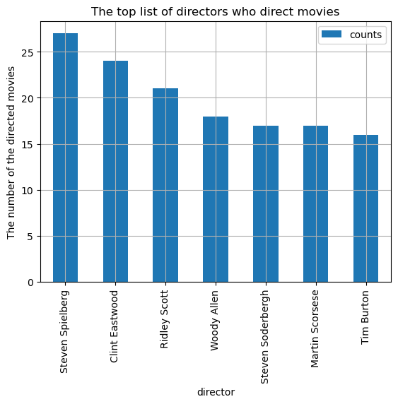

```python
# Plot scatter diagram showing the directors ranking order
directors_top.plot(x="director", y="counts", kind="bar");
plt.legend()
plt.ylabel('The number of the directed movies')
plt.title('The top list of directors who direct movies')
plt.grid(True)
```

#### A bar chart visually illustrates the result obtained from the above table. Steven Spielberg has the highest bar.

### Research Question 2:Who are the most actors who have played a starring roles in movies?

```python
# Extract actors list from movie data frame with their value counts (The number of times the actor starring a movie )
actors = movie['cast'].value_counts(dropna=True, sort=True)
```

```python
#Check the created list
actors.info()
```

```
<class 'pandas.core.series.Series'>
Index: 1425 entries, Nicolas Cage to Stephen Boyd
Series name: cast
Non-Null Count  Dtype
--------------  -----
1425 non-null   int64
dtypes: int64(1)
memory usage: 22.3+ KB
```

```python
# Extract a data from actors list and rename columns
actors = actors.rename_axis('actor').reset_index(name='counts')
```

```python
# Check the created data frame
actors
```

|  | actor | counts |
| --- | --- | --- |
| 0 | Nicolas Cage | 37 |
| 1 | Bruce Willis | 32 |
| 2 | Johnny Depp | 30 |
| 3 | Sylvester Stallone | 29 |
| 4 | Robert De Niro | 28 |
| ... | ... | ... |
| 1420 | Robert Patrick | 1 |
| 1421 | Denis Leary | 1 |
| 1422 | Joe Mantegna | 1 |
| 1423 | Ice-T | 1 |
| 1424 | Stephen Boyd | 1 |

1425 rows × 2 columns

```python
# Extract onyly a data frame with the actors contribut in starring films more than 26 times
actors_top = actors.where(actors['counts'] >26)
```

```python
# Check the created data frame
actors_top
```

|  | actor | counts |
| --- | --- | --- |
| 0 | Nicolas Cage | 37.0 |
| 1 | Bruce Willis | 32.0 |
| 2 | Johnny Depp | 30.0 |
| 3 | Sylvester Stallone | 29.0 |
| 4 | Robert De Niro | 28.0 |
| ... | ... | ... |
| 1420 | NaN | NaN |
| 1421 | NaN | NaN |
| 1422 | NaN | NaN |
| 1423 | NaN | NaN |
| 1424 | NaN | NaN |

1425 rows × 2 columns

```python
# Delete the rows with NaN values
actors_top.dropna(inplace=True)
```

```python
# Check the created list after removal of NaN values
actors_top
```

|  | actor | counts |
| --- | --- | --- |
| 0 | Nicolas Cage | 37.0 |
| 1 | Bruce Willis | 32.0 |
| 2 | Johnny Depp | 30.0 |
| 3 | Sylvester Stallone | 29.0 |
| 4 | Robert De Niro | 28.0 |
| 5 | Denzel Washington | 28.0 |
| 6 | Tom Hanks | 28.0 |
| 7 | Tom Cruise | 27.0 |

#### A table shows the top-ranked stars who act in a large number of movies. It can be noticed that Nicolas Cage is at the top of the list.

```python
# Make the actor column as a row index to prepare for the pie chart
actors_top = actors_top.set_index('actor')
```

```python
# Check the data frame after the modification performed on
actors_top
```

| actor | counts |
| --- | --- |
| Nicolas Cage | 37.0 |
| Bruce Willis | 32.0 |
| Johnny Depp | 30.0 |
| Sylvester Stallone | 29.0 |
| Robert De Niro | 28.0 |
| Denzel Washington | 28.0 |
| Tom Hanks | 28.0 |
| Tom Cruise | 27.0 |

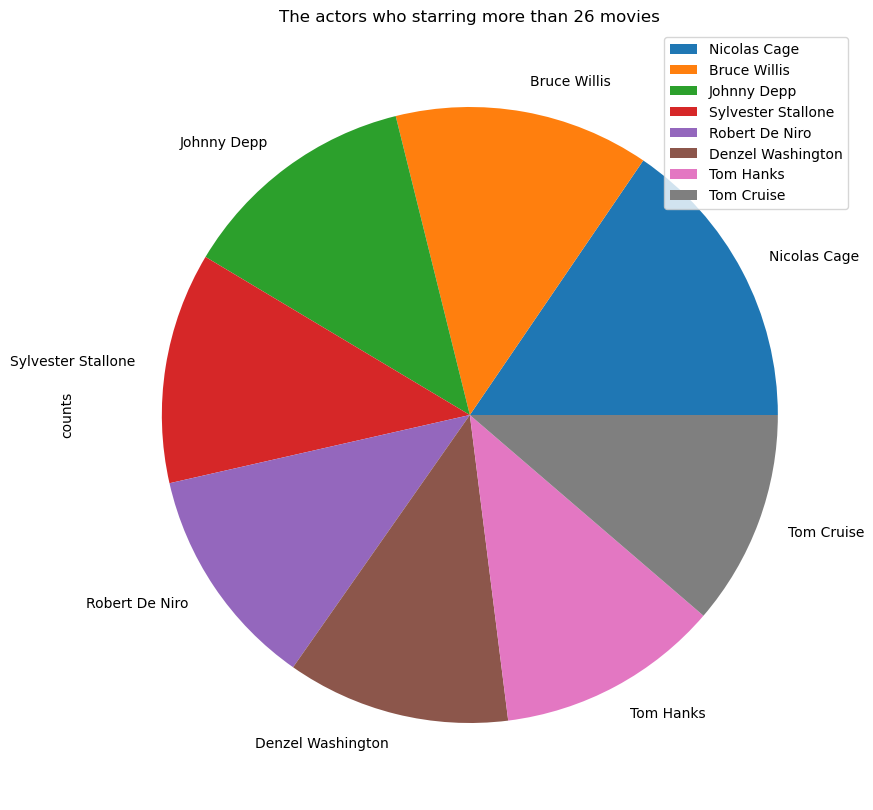

```python
# Creae a pie plot with actors list that starring more than 26 movies
plot =actors_top.plot.pie(y='counts', figsize=(10, 10))
plt.title('The actors who starring more than 26 movies')
```

#### A pie chart illustrates visually the percentage of each star who acts in a larger number of movies. It can be noticed the percentages are close and Nicolas Cage has the higher portion of the pie (more contributions to the movies have been produced).

[figure not shown]

```python
# Create a horizontal bar plot with actors list that starring more than 26 movies
ax = actors_top.plot.barh(color = 'orange', )
plt.legend()
plt.xlabel('The number of the times the actor starring a movie')
plt.title('The top list of directors who direct movies')
plt.grid(True)
```

#### A horizontal bar chart more illustrates visually the result highlited by the above table and pie chart.

### Research Question 3:How is the revenue associated to the average voting score?

```python
# Chek for the name of the columns in the original data frame movie
movie.head(0)
```

|  | popularity | original_title | cast | director | runtime | genres | vote_count | vote_average | release_year | budget | revenue |
| --- | --- | --- | --- | --- | --- | --- | --- | --- | --- | --- | --- |

```python
# Extract a sub data frame from movie data frame containing revenue, vote_average and vote_counts
rev_vote = movie[["revenue", "vote_count",'vote_average']]
```

```python
# Set a criteria to not count rows with vote counts less than or equal 100
rev_vote = rev_vote[rev_vote["vote_count"] >100 ]
```

```python
# Check the created data frame
rev_vote.info()
```

```
<class 'pandas.core.frame.DataFrame'>
Int64Index: 2603 entries, 0 to 10770
Data columns (total 3 columns):
 #   Column        Non-Null Count  Dtype
---  ------        --------------  -----
 0   revenue       2603 non-null   float64
 1   vote_count    2603 non-null   int64
 2   vote_average  2603 non-null   float64
dtypes: float64(2), int64(1)
memory usage: 81.3 KB
```

```python
# Check the mean value of each column and have some statistical indication about the created data frame
rev_vote.describe()
```

|  | revenue | vote_count | vote_average |
| --- | --- | --- | --- |
| count | 2.603000e+03 | 2603.000000 | 2603.000000 |
| mean | 1.867443e+08 | 758.845947 | 6.316980 |
| std | 2.448018e+08 | 990.783437 | 0.750216 |
| min | 2.861934e+00 | 101.000000 | 3.300000 |
| 25% | 4.279320e+07 | 198.000000 | 5.800000 |
| 50% | 1.040340e+08 | 389.000000 | 6.300000 |
| 75% | 2.300004e+08 | 852.500000 | 6.900000 |
| max | 2.827124e+09 | 9767.000000 | 8.400000 |

```python
# Take a sub data for the movies with revenues less than the revenue mean
# Then observe how the avg vote affected
rev_low = rev_vote[rev_vote["revenue"] <= 1.867443e+08 ]
```

```python
# Observe the mean values for the created data frame
rev_low.describe()
```

|  | revenue | vote_count | vote_average |
| --- | --- | --- | --- |
| count | 1.791000e+03 | 1791.000000 | 1791.000000 |
| mean | 7.181494e+07 | 454.499721 | 6.238191 |
| std | 5.168518e+07 | 479.804789 | 0.756672 |
| min | 2.861934e+00 | 101.000000 | 3.300000 |
| 25% | 2.801975e+07 | 171.000000 | 5.700000 |
| 50% | 6.338060e+07 | 289.000000 | 6.200000 |
| 75% | 1.089132e+08 | 549.500000 | 6.800000 |
| max | 1.862992e+08 | 5923.000000 | 8.400000 |

#### A table shows a statistical characteristics of each column in rev_low data fram. The study focus on the association between the revenue and the average voting score and who voting score varies in the low and high revenue portions. The study for these variations taking the range of revenues under and above its mean in the vote_rev data frame as interperated below.

```python
# Define a function to plot a scatter diagram illustrates the correlation between the revenue and the average voting score
def scatter_plot(df,i,j,k,l,m,z):
    ax = df.plot.scatter(x= i, y= j , color = k)
    ax.legend([i, j])
    ax.legend([i, j])
    plt.xlabel(l)
    plt.ylabel(m)
    plt.title(z)
    plt.grid(True)
```

```python
# Define a function to plot the density distribution for the average voting score for the created data frame rev_low
def kde_plot(df,i,j,l,m,n):
    df.plot(x=i, y=j, kind='kde');
    plt.legend()
    plt.xlabel(l)
    plt.ylabel(m)
    plt.title(n)
    plt.grid(True)
```

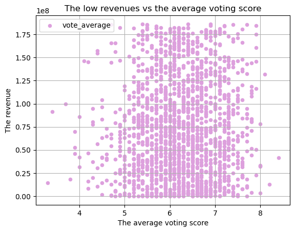

```python
# Plot a scatter diagram illustrates the correlation between the revenue and the average voting score
scatter_plot(rev_low,'vote_average','revenue', 'plum','The average voting score', 'The revenue','The low revenues vs the average voting score' )
```

#### A scatter diagram showing the correlation between the low revenues (the portion of revenues under the mean value of revenue in rev_vote data frame) and the corresponding average voting score.

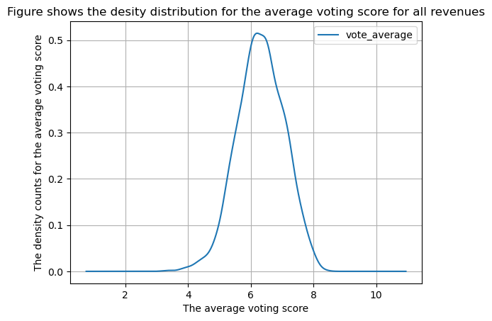

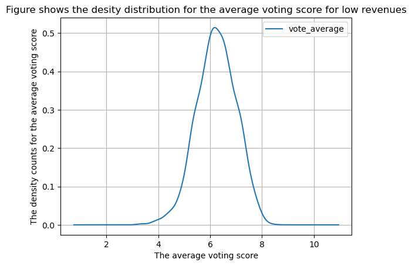

```python
# Plot the density distribution for the average voting score for the created data frame rev_low
kde_plot(rev_vote,"revenue","vote_average",'The average voting score','The density counts for the average voting score','Figure shows the desity distribution for the average voting score for all revenues')
kde_plot(rev_low,"revenue","vote_average",'The average voting score','The density counts for the average voting score','Figure shows the desity distribution for the average voting score for low revenues')
```

#### Density distribution curves for the voting score corresponding to the mean of the revenue in the rev_vote and rev_low data frames show that the mean of the voting score shifted left (becomes less in value from 6.32 to 6.24). Both curves show almost ideal normal distribution bell shapes.

```python
# Take a sub data frame for the movies with revenues more than the revenue mean showed above for rev_vote
# Then observe how the avg vote affected
rev_high = rev_vote[rev_vote['revenue'] > 1.867443e+08]
```

```python
rev_high.describe()
```

|  | revenue | vote_count | vote_average |
| --- | --- | --- | --- |
| count | 8.120000e+02 | 812.000000 | 812.000000 |
| mean | 4.402400e+08 | 1430.131773 | 6.490764 |
| std | 3.047400e+08 | 1409.136957 | 0.705763 |
| min | 1.871533e+08 | 103.000000 | 4.200000 |
| 25% | 2.419284e+08 | 443.750000 | 6.000000 |
| 50% | 3.359314e+08 | 925.000000 | 6.500000 |
| 75% | 5.289304e+08 | 1941.000000 | 7.000000 |
| max | 2.827124e+09 | 9767.000000 | 8.300000 |

###### We can observe that the average voting score mean is increased

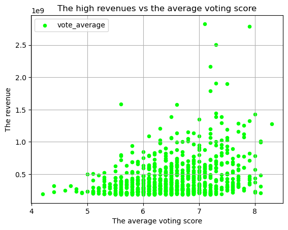

```python
# Plot a scattter diagram showing the correlation between the revenue and the average voting score
scatter_plot(rev_high,'vote_average','revenue', 'lime','The average voting score', 'The revenue','The high revenues vs the average voting score' )
```

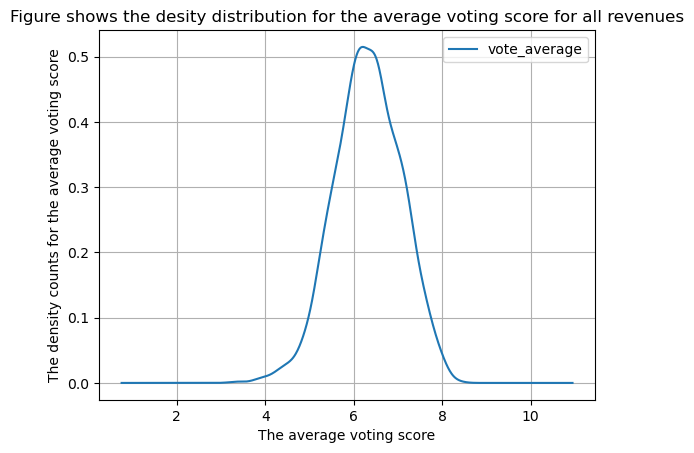

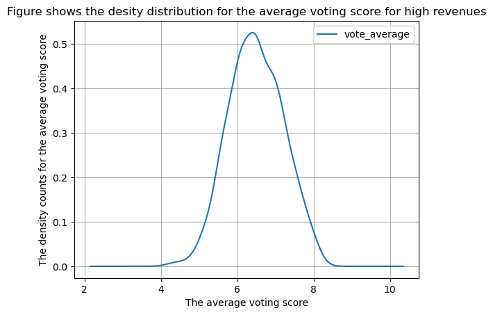

```python
# Plot the density distribution for the average voting score for the created data frame rev_high
kde_plot(rev_vote,"revenue","vote_average",'The average voting score','The density counts for the average voting score','Figure shows the desity distribution for the average voting score for all revenues')
kde_plot(rev_high,"revenue","vote_average",'The average voting score','The density counts for the average voting score','Figure shows the desity distribution for the average voting score for high revenues')
```

#### Density distribution curves for the voting score corresponding to the mean of the revenue in the rev_vote and rev_high data frames show that the mean of the voting score shifted right (becomes higher in value from 6.32 to 6.49). Both curves show almost ideal normal distribution bell shapes.

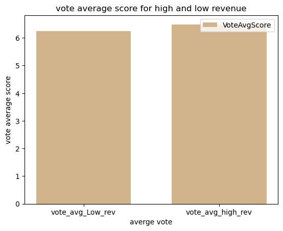

```python
# Comparing the mean of avg voting score for the ranges of high and low revenues
locations = [1, 2]
heights = [rev_low['vote_average'].mean(),rev_high['vote_average'].mean()]
labels = ['vote_avg_Low_rev', 'vote_avg_high_rev']
plt.bar(locations, heights, tick_label=labels, color = 'tan', width = 0.7)
plt.legend(['VoteAvgScore'])
plt.title('vote average score for high and low revenue')
plt.xlabel('averge vote')
plt.ylabel('vote average score');
```

#### A simple bar chart illustrates and summarizes what has been mentioned above the mean voting score increased from the lower portion of the revenue to the higher one (from 6.24 to 6.49). Taking into consideration its value is 6.32 for the whole distribution of the revenue.

### Research Question 4:How is the revenue associated to the different genres ?

```python
# Refer to the original data frame movie to remember columns names
movie.head(0)
```

|  | popularity | original_title | cast | director | runtime | genres | vote_count | vote_average | release_year | budget | revenue |
| --- | --- | --- | --- | --- | --- | --- | --- | --- | --- | --- | --- |

```python
# Extract a sub date fram from the movie data frame
rev_gen = movie[["revenue", "genres",'vote_count']]
```

```python
# Set criteria taking only the rows for vote count more than 100
rev_gen = rev_gen[rev_gen['vote_count'] > 100]
```

```python
# Check the chracteristices for the newly created through displaying 5 header lines
rev_gen.head(5)
```

|  | revenue | genres | vote_count |
| --- | --- | --- | --- |
| 0 | 1.392446e+09 | Action | 5562 |
| 1 | 3.481613e+08 | Action | 6185 |
| 2 | 2.716190e+08 | Adventure | 2480 |
| 3 | 1.902723e+09 | Action | 5292 |
| 4 | 1.385749e+09 | Action | 2947 |

```python
# Check the chracteristices for the newly created data frame
rev_gen.info()
```

```
<class 'pandas.core.frame.DataFrame'>
Int64Index: 2603 entries, 0 to 10770
Data columns (total 3 columns):
 #   Column      Non-Null Count  Dtype
---  ------      --------------  -----
 0   revenue     2603 non-null   float64
 1   genres      2603 non-null   object
 2   vote_count  2603 non-null   int64
dtypes: float64(1), int64(1), object(1)
memory usage: 81.3+ KB
```

```python
# Check some statistics for the newly created data frame
rev_gen.describe()
```

|  | revenue | vote_count |
| --- | --- | --- |
| count | 2.603000e+03 | 2603.000000 |
| mean | 1.867443e+08 | 758.845947 |
| std | 2.448018e+08 | 990.783437 |
| min | 2.861934e+00 | 101.000000 |
| 25% | 4.279320e+07 | 198.000000 |
| 50% | 1.040340e+08 | 389.000000 |
| 75% | 2.300004e+08 | 852.500000 |
| max | 2.827124e+09 | 9767.000000 |

```python
# Check the value counts (the number of the movies with the same genre)
rev_gen['genres'].value_counts()
```

```
Drama              532
Comedy             492
Action             487
Adventure          265
Horror             180
Thriller           120
Crime              116
Animation           87
Fantasy             84
Science Fiction     78
Romance             46
Family              32
Mystery             25
Music               18
War                 12
History             12
Western              9
Documentary          8
Name: genres, dtype: int64
```

```python
# Extract sub data frame expres the total revenue of each genere and order this data frane desndingly
rev_gen = rev_gen.groupby('genres')['revenue'].sum().reset_index().sort_values(by=['revenue'], ascending=False)
```

```python
# Check the newly created data fram
rev_gen
```

|  | genres | revenue |
| --- | --- | --- |
| 0 | Action | 1.023109e+11 |
| 1 | Adventure | 9.360027e+10 |
| 6 | Drama | 7.017191e+10 |
| 3 | Comedy | 6.935679e+10 |
| 2 | Animation | 3.003029e+10 |
| 8 | Fantasy | 2.069463e+10 |
| 14 | Science Fiction | 2.061666e+10 |
| 10 | Horror | 1.935794e+10 |
| 4 | Crime | 1.536464e+10 |
| 15 | Thriller | 1.356438e+10 |
| 7 | Family | 1.045906e+10 |
| 13 | Romance | 7.851427e+09 |
| 11 | Music | 3.150872e+09 |
| 12 | Mystery | 2.812957e+09 |
| 16 | War | 2.518649e+09 |
| 9 | History | 2.473609e+09 |
| 17 | Western | 1.345529e+09 |
| 5 | Documentary | 4.149884e+08 |

#### A table shows the rank of the movies' genres based on their portion of the total revenue. It can be noticed that action movies are at the top.

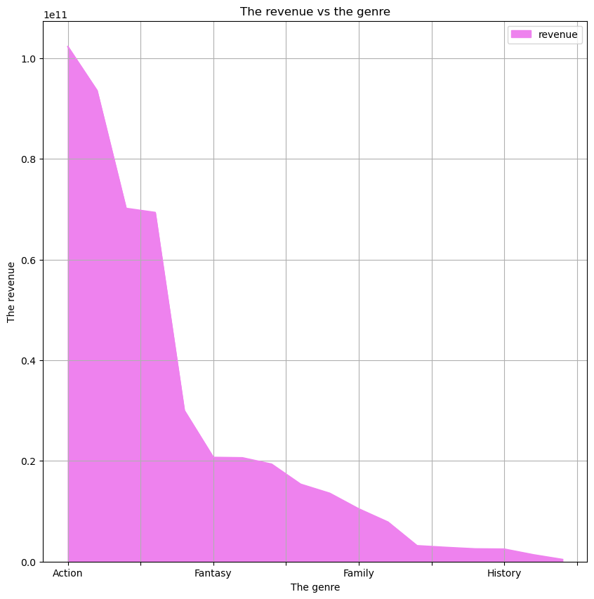

```python
# Using area plot to show the highest genere revenue
rev_gen.plot(x='genres', y="revenue", kind="area", figsize=(10, 10), color = 'violet')
plt.legend()
plt.xlabel('The genre')
plt.ylabel('The revenue')
plt.title('The revenue vs the genre')
plt.grid(True)
```

#### An area chart visually illustrates the results of the above table. It is easily noted that action and adventure movies are the top two ranks regarding revenue.

```python
#Convert the column genre as row index for the extracted data frame to prepare for pie chart
rev_gen = rev_gen.set_index('genres')
```

```python
# Check the modification performed on the rev_gen data frame
rev_gen
```

| genres | revenue |
| --- | --- |
| Action | 1.023109e+11 |
| Adventure | 9.360027e+10 |
| Drama | 7.017191e+10 |
| Comedy | 6.935679e+10 |
| Animation | 3.003029e+10 |
| Fantasy | 2.069463e+10 |
| Science Fiction | 2.061666e+10 |
| Horror | 1.935794e+10 |
| Crime | 1.536464e+10 |
| Thriller | 1.356438e+10 |
| Family | 1.045906e+10 |
| Romance | 7.851427e+09 |
| Music | 3.150872e+09 |
| Mystery | 2.812957e+09 |
| War | 2.518649e+09 |
| History | 2.473609e+09 |
| Western | 1.345529e+09 |
| Documentary | 4.149884e+08 |

```python
# Mask for the revenue values over certain limit to just make the chart more clear
rev_gen = rev_gen[rev_gen['revenue'] > 1.852850e+09]
```

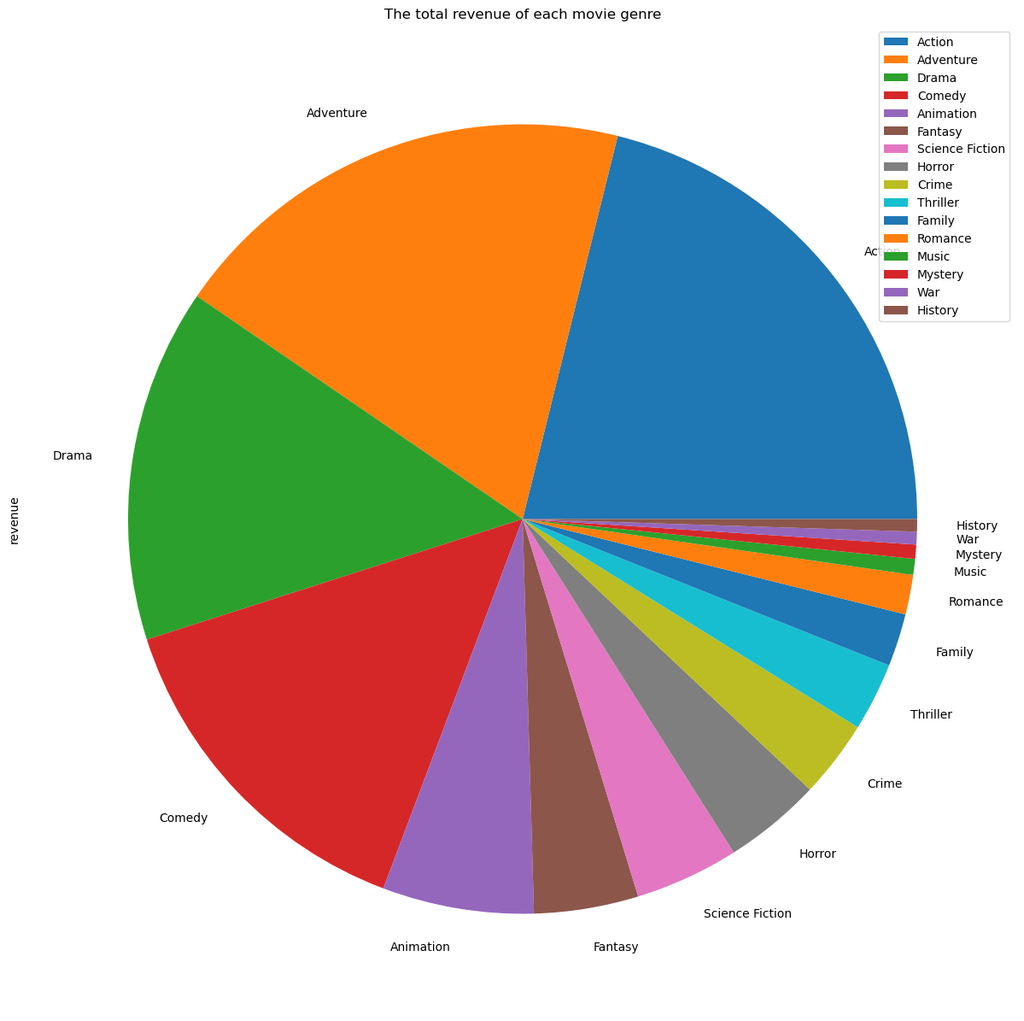

```python
# Plot a pie chart comparing the contribution for each genre to the revenue
plot = rev_gen.plot.pie(y='revenue', figsize=(15, 15))
plt.title('The total revenue of each movie genre')
```

### Research question 5: How is the genres associated to the average voting score? and does this associacion reflect on the revenue?

```python
# Refer to movie data fram to get columns names
movie.head(0)
```

|  | popularity | original_title | cast | director | runtime | genres | vote_count | vote_average | release_year | budget | revenue |
| --- | --- | --- | --- | --- | --- | --- | --- | --- | --- | --- | --- |

```python
# Extract sub data from from the original one movie data frame
gen_vote = movie[["genres", "vote_count", 'vote_average']]
```

```python
# Set criteria taking only the rows for vote count more than 100
gen_vote = gen_vote.query('vote_count > 100')
```

```python
# Check 10 rows as a rondom sample from the created data frame
gen_vote.sample(100)
```

|  | genres | vote_count | vote_average |
| --- | --- | --- | --- |
| 7638 | Action | 120 | 4.9 |
| 8323 | Adventure | 153 | 6.2 |
| 1534 | Animation | 284 | 6.0 |
| 34 | Adventure | 600 | 6.2 |
| 6091 | Drama | 517 | 6.6 |
| ... | ... | ... | ... |
| 1923 | Adventure | 3467 | 7.4 |
| 3934 | Drama | 944 | 6.7 |
| 4390 | Comedy | 1180 | 6.0 |
| 8750 | Drama | 341 | 7.0 |
| 1974 | Drama | 530 | 6.9 |

100 rows × 3 columns

```python
# Get the overall charchteristics of the created data frame
gen_vote.info()
```

```
<class 'pandas.core.frame.DataFrame'>
Int64Index: 2603 entries, 0 to 10770
Data columns (total 3 columns):
 #   Column        Non-Null Count  Dtype
---  ------        --------------  -----
 0   genres        2603 non-null   object
 1   vote_count    2603 non-null   int64
 2   vote_average  2603 non-null   float64
dtypes: float64(1), int64(1), object(1)
memory usage: 81.3+ KB
```

```python
# Check the value counts of genre (the total number each genre assigned the movies)
gen_vote.value_counts()
```

```
genres   vote_count  vote_average
Drama    125         6.1             2
         103         6.6             2
Comedy   145         6.5             2
Drama    124         6.6             2
         185         6.2             2
                                    ..
Comedy   116         6.4             1
         117         6.0             1
                     6.2             1
                     6.8             1
Western  3929        7.2             1
Length: 2579, dtype: int64
```

```python
# Create a list from the sub data frame gen_vote for each genre count
gen_vote_norm = gen_vote.genres.value_counts()
```

```python
gen_vote_norm
```

```
Drama              532
Comedy             492
Action             487
Adventure          265
Horror             180
Thriller           120
Crime              116
Animation           87
Fantasy             84
Science Fiction     78
Romance             46
Family              32
Mystery             25
Music               18
War                 12
History             12
Western              9
Documentary          8
Name: genres, dtype: int64
```

```python
# Convert the list to data frame
gen_vote_norm = pd.DataFrame(gen_vote_norm)
```

```python
gen_vote_norm
```

|  | genres |
| --- | --- |
| Drama | 532 |
| Comedy | 492 |
| Action | 487 |
| Adventure | 265 |
| Horror | 180 |
| Thriller | 120 |
| Crime | 116 |
| Animation | 87 |
| Fantasy | 84 |
| Science Fiction | 78 |
| Romance | 46 |
| Family | 32 |
| Mystery | 25 |
| Music | 18 |
| War | 12 |
| History | 12 |
| Western | 9 |
| Documentary | 8 |

```python
# Convert the row genre to column
gen_vote_norm.reset_index(level=0, inplace=True)
```

```python
# Check if the conversion has been performed
gen_vote_norm
```

|  | index | genres |
| --- | --- | --- |
| 0 | Drama | 532 |
| 1 | Comedy | 492 |
| 2 | Action | 487 |
| 3 | Adventure | 265 |
| 4 | Horror | 180 |
| 5 | Thriller | 120 |
| 6 | Crime | 116 |
| 7 | Animation | 87 |
| 8 | Fantasy | 84 |
| 9 | Science Fiction | 78 |
| 10 | Romance | 46 |
| 11 | Family | 32 |
| 12 | Mystery | 25 |
| 13 | Music | 18 |
| 14 | War | 12 |
| 15 | History | 12 |
| 16 | Western | 9 |
| 17 | Documentary | 8 |

```python
# Rename the new data fram columns
# Now we should get one column with genres and other for thier counts
gen_vote_norm.rename(columns = {'index':'genres_1', 'genres':'gen_counts'}, inplace = True)
```

```python
# Check if the modifications have been performed
gen_vote_norm
```

|  | genres_1 | gen_counts |
| --- | --- | --- |
| 0 | Drama | 532 |
| 1 | Comedy | 492 |
| 2 | Action | 487 |
| 3 | Adventure | 265 |
| 4 | Horror | 180 |
| 5 | Thriller | 120 |
| 6 | Crime | 116 |
| 7 | Animation | 87 |
| 8 | Fantasy | 84 |
| 9 | Science Fiction | 78 |
| 10 | Romance | 46 |
| 11 | Family | 32 |
| 12 | Mystery | 25 |
| 13 | Music | 18 |
| 14 | War | 12 |
| 15 | History | 12 |
| 16 | Western | 9 |
| 17 | Documentary | 8 |

```python
# Create a second data frame represents the total avg vote score per each genre
gen_vote = gen_vote.groupby('genres')['vote_average'].sum().reset_index().sort_values(by=['vote_average'], ascending=False)
```

```python
# Check the newly created data frame
gen_vote
```

|  | genres | vote_average |
| --- | --- | --- |
| 6 | Drama | 3544.9 |
| 3 | Comedy | 3028.1 |
| 0 | Action | 2986.3 |
| 1 | Adventure | 1680.4 |
| 10 | Horror | 1074.1 |
| 4 | Crime | 767.2 |
| 15 | Thriller | 735.9 |
| 2 | Animation | 563.7 |
| 8 | Fantasy | 522.1 |
| 14 | Science Fiction | 496.4 |
| 13 | Romance | 301.1 |
| 7 | Family | 196.3 |
| 12 | Mystery | 155.2 |
| 11 | Music | 113.8 |
| 9 | History | 81.4 |
| 16 | War | 80.1 |
| 17 | Western | 60.8 |
| 5 | Documentary | 55.3 |

```python
# Convert index of the data frame gen_vote to column as step to reorder the DF
gen_vote = gen_vote.reset_index()
```

```python
gen_vote
```

|  | index | genres | vote_average |
| --- | --- | --- | --- |
| 0 | 6 | Drama | 3544.9 |
| 1 | 3 | Comedy | 3028.1 |
| 2 | 0 | Action | 2986.3 |
| 3 | 1 | Adventure | 1680.4 |
| 4 | 10 | Horror | 1074.1 |
| 5 | 4 | Crime | 767.2 |
| 6 | 15 | Thriller | 735.9 |
| 7 | 2 | Animation | 563.7 |
| 8 | 8 | Fantasy | 522.1 |
| 9 | 14 | Science Fiction | 496.4 |
| 10 | 13 | Romance | 301.1 |
| 11 | 7 | Family | 196.3 |
| 12 | 12 | Mystery | 155.2 |
| 13 | 11 | Music | 113.8 |
| 14 | 9 | History | 81.4 |
| 15 | 16 | War | 80.1 |
| 16 | 17 | Western | 60.8 |
| 17 | 5 | Documentary | 55.3 |

```python
# Remove the column named index
gen_vote = gen_vote.drop('index', axis=1)
```

```python
# Check the modified data frame
gen_vote
```

|  | genres | vote_average |
| --- | --- | --- |
| 0 | Drama | 3544.9 |
| 1 | Comedy | 3028.1 |
| 2 | Action | 2986.3 |
| 3 | Adventure | 1680.4 |
| 4 | Horror | 1074.1 |
| 5 | Crime | 767.2 |
| 6 | Thriller | 735.9 |
| 7 | Animation | 563.7 |
| 8 | Fantasy | 522.1 |
| 9 | Science Fiction | 496.4 |
| 10 | Romance | 301.1 |
| 11 | Family | 196.3 |
| 12 | Mystery | 155.2 |
| 13 | Music | 113.8 |
| 14 | History | 81.4 |
| 15 | War | 80.1 |
| 16 | Western | 60.8 |
| 17 | Documentary | 55.3 |

```python
# Merge gen_vote data frame with gen_vote_norm data frame
gen_vote_comb = gen_vote.merge(gen_vote_norm, left_on='genres', right_on='genres_1', how='inner')
```

```python
# Chech the combined data frame has been created as required
gen_vote_comb
```

|  | genres | vote_average | genres_1 | gen_counts |
| --- | --- | --- | --- | --- |
| 0 | Drama | 3544.9 | Drama | 532 |
| 1 | Comedy | 3028.1 | Comedy | 492 |
| 2 | Action | 2986.3 | Action | 487 |
| 3 | Adventure | 1680.4 | Adventure | 265 |
| 4 | Horror | 1074.1 | Horror | 180 |
| 5 | Crime | 767.2 | Crime | 116 |
| 6 | Thriller | 735.9 | Thriller | 120 |
| 7 | Animation | 563.7 | Animation | 87 |
| 8 | Fantasy | 522.1 | Fantasy | 84 |
| 9 | Science Fiction | 496.4 | Science Fiction | 78 |
| 10 | Romance | 301.1 | Romance | 46 |
| 11 | Family | 196.3 | Family | 32 |
| 12 | Mystery | 155.2 | Mystery | 25 |
| 13 | Music | 113.8 | Music | 18 |
| 14 | History | 81.4 | History | 12 |
| 15 | War | 80.1 | War | 12 |
| 16 | Western | 60.8 | Western | 9 |
| 17 | Documentary | 55.3 | Documentary | 8 |

```python
# DEVIDE COLUMN OF AVG VOTE by GEN COUNTS TO GET THE AVG VOTE SCORE PER GENRE
gen_vote_comb ['vote_avg_per_genre'] = gen_vote_comb['vote_average']/gen_vote_comb ['gen_counts']
```

```python
# Check the result of the division process
gen_vote_comb
```

|  | genres | vote_average | genres_1 | gen_counts | vote_avg_per_genre |
| --- | --- | --- | --- | --- | --- |
| 0 | Drama | 3544.9 | Drama | 532 | 6.663346 |
| 1 | Comedy | 3028.1 | Comedy | 492 | 6.154675 |
| 2 | Action | 2986.3 | Action | 487 | 6.132033 |
| 3 | Adventure | 1680.4 | Adventure | 265 | 6.341132 |
| 4 | Horror | 1074.1 | Horror | 180 | 5.967222 |
| 5 | Crime | 767.2 | Crime | 116 | 6.613793 |
| 6 | Thriller | 735.9 | Thriller | 120 | 6.132500 |
| 7 | Animation | 563.7 | Animation | 87 | 6.479310 |
| 8 | Fantasy | 522.1 | Fantasy | 84 | 6.215476 |
| 9 | Science Fiction | 496.4 | Science Fiction | 78 | 6.364103 |
| 10 | Romance | 301.1 | Romance | 46 | 6.545652 |
| 11 | Family | 196.3 | Family | 32 | 6.134375 |
| 12 | Mystery | 155.2 | Mystery | 25 | 6.208000 |
| 13 | Music | 113.8 | Music | 18 | 6.322222 |
| 14 | History | 81.4 | History | 12 | 6.783333 |
| 15 | War | 80.1 | War | 12 | 6.675000 |
| 16 | Western | 60.8 | Western | 9 | 6.755556 |
| 17 | Documentary | 55.3 | Documentary | 8 | 6.912500 |

```python
# DELETE UN REQUIRED COLUMNS AS WE NEED TEH RELATION BETWEEN GENRES AND AVG VOTE SCORE PER GENRE
gen_vote_comb.drop(gen_vote_comb.columns[[1,2,3]],axis = 1,inplace=True)
gen_vote_comb
```

|  | genres | vote_avg_per_genre |
| --- | --- | --- |
| 0 | Drama | 6.663346 |
| 1 | Comedy | 6.154675 |
| 2 | Action | 6.132033 |
| 3 | Adventure | 6.341132 |
| 4 | Horror | 5.967222 |
| 5 | Crime | 6.613793 |
| 6 | Thriller | 6.132500 |
| 7 | Animation | 6.479310 |
| 8 | Fantasy | 6.215476 |
| 9 | Science Fiction | 6.364103 |
| 10 | Romance | 6.545652 |
| 11 | Family | 6.134375 |
| 12 | Mystery | 6.208000 |
| 13 | Music | 6.322222 |
| 14 | History | 6.783333 |
| 15 | War | 6.675000 |
| 16 | Western | 6.755556 |
| 17 | Documentary | 6.912500 |

```python
# Order the DF combined desendingly
gen_vote_comb = gen_vote_comb.sort_values(by=['vote_avg_per_genre'], ascending=False)
```

```python
# Check the ordering process has been performed on the combined data frame
gen_vote_comb
```

|  | genres | vote_avg_per_genre |
| --- | --- | --- |
| 17 | Documentary | 6.912500 |
| 14 | History | 6.783333 |
| 16 | Western | 6.755556 |
| 15 | War | 6.675000 |
| 0 | Drama | 6.663346 |
| 5 | Crime | 6.613793 |
| 10 | Romance | 6.545652 |
| 7 | Animation | 6.479310 |
| 9 | Science Fiction | 6.364103 |
| 3 | Adventure | 6.341132 |
| 13 | Music | 6.322222 |
| 8 | Fantasy | 6.215476 |
| 12 | Mystery | 6.208000 |
| 1 | Comedy | 6.154675 |
| 11 | Family | 6.134375 |
| 6 | Thriller | 6.132500 |
| 2 | Action | 6.132033 |
| 4 | Horror | 5.967222 |

#### A table shows the genres and their corresponding average voting score. It can be noticed that documentary movies have higher scores.

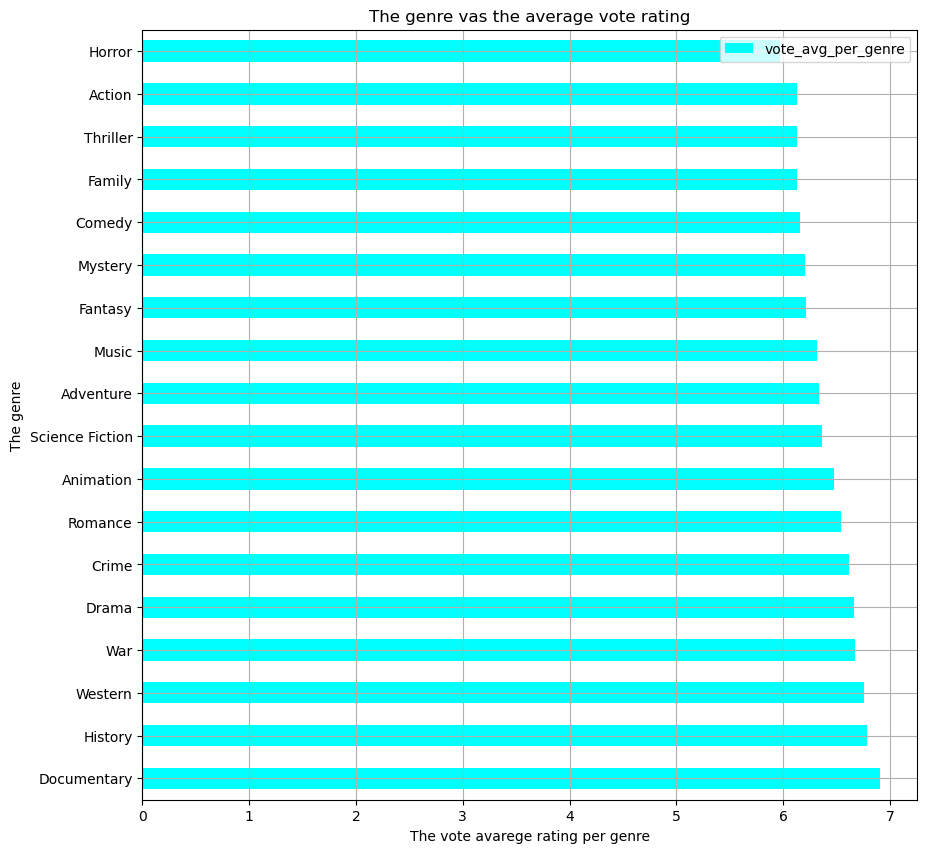

```python
# Plot horizontal bar chart
gen_vote_comb.plot(x='genres', y="vote_avg_per_genre", kind="barh", figsize=(10, 10), color = 'aqua')
plt.legend()
plt.xlabel('The vote avarege rating per genre')
plt.ylabel('The genre')
plt.title('The genre vas the average vote rating')
plt.grid(True)
```

#### A horizontal bar chart visually illustrates the result reached by the above table. It also shows that all genres are very close in the voting score.

# Research question 6: Does the budget increase has an effect on revenue?

```python
# Refer to the original data frame movie get the required columns names
movie.head(0)
```

|  | popularity | original_title | cast | director | runtime | genres | vote_count | vote_average | release_year | budget | revenue |
| --- | --- | --- | --- | --- | --- | --- | --- | --- | --- | --- | --- |

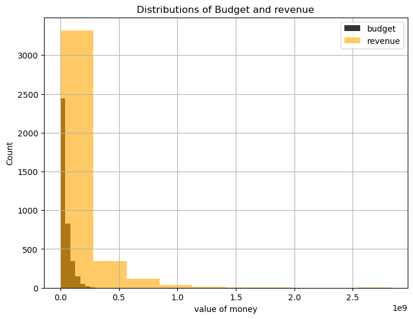

```python
# Plot the bar chart for these 2 variables (budget and revenue) to gether
fig, ax = plt.subplots(figsize =(8,6))
ax.hist(movie['budget'], alpha=0.8, color = 'black', label='budget')
ax.hist(movie['revenue'], alpha=0.6,color = 'orange', label='revenue')
ax.set_title('Distributions of Budget and revenue')
ax.set_xlabel('value of money')
ax.set_ylabel('Count')
ax.legend(loc='upper right')
plt.grid(True)
plt.show();
```

## Conclusions

The answers to the research questions are:

1. Who are the directors who most direct films?

Steven Spielberg

1. Who are the most actors who have played a starring role in movies?

Nicolas Cage

1. How is the revenue associated with the average voting score?

We can see that the high revenues are connected to the higher average voting score rating.

1. How is the revenue associated with the different genres?

We can see that action movie have the highest revenues adventures and Drama.

1. How are the genres associated with the average voting score? and does this association reflect on the revenue?

Although we observe that higher revenues are associated with higher average voting score ratings, the genres with high revenues aren't those of higher average voting scores. The highest genre average voting score rating is the documentary. This result may refer to the criteria of vote counts exceeds 100 should be increased further example becomes 500